# Boosting

# Boosting

## The basic challenge

- Take a weak learner (one slightly better than random guessing)
- Turn it into a strong learner (one with arbitrary accuracy)

## The conceptual implementation

- Fit a learner to your data
- Evaluate the residuals
- Fit a learner to the residuals
- Grab the predictions from this model (which should correct the errors from the first model)
- Add the predictions to form your new predictions
- Repeat M times

## The conceptual implementation

$$F(x) = \sum_{i=1}^M F_i(x)$$

- Once we fit a learner, we keep its prediction
- We want to improve the prediction by seeing where it went wrong
- Predict the degree to which it went wrong
- Correct the original predictions

## The conceptual model

- $h(x)$ is a weak learner
- Fit $F_1(x)$ to your data
- $F_2(x) = F_1(x) + h(x)$
- $F_3(x) = F_2(x) + h(x)$
- and so on, for *M* iterations

# Gradient descent

## Gradient descent

- Gradient descent is a way to minimize a function
- The idea is to follow a curve down its **steepest** path

## Gradient descent

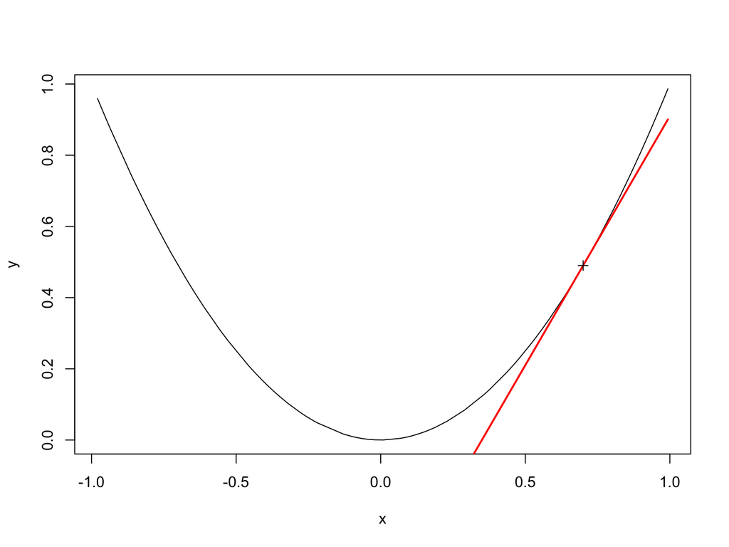

## Gradient Descent

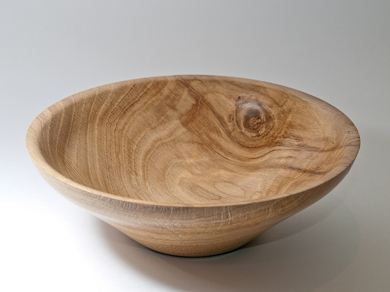

## Gradient Descent

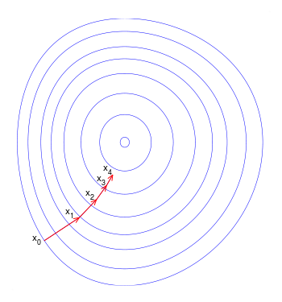

## Gradient descent

- Conceptually think of residuals
- However, in reality, think in direction of gradient

## Squared error loss

- $L(y, x) = (y_i - x_i)^2/2$
- Gradient $G(x, y) = - (y_i - x_i)$
- Note that this is essentially the residual

## Logistic loss

- $L(y,x) = \log(1 + e^{-yx})$
- Gradient $G(x,y) = -ye^{-yx}/(1+e^{-yx})$
- This is often used for binary targets, where $y\in {0,1}$, and $x$ is the predicted probabilities

# Stochastic Gradient Descent

## Stochastic Gradient Descent

- We can overfit our data using just gradient descent
- Instead, fit learner to random subset of data, predict on remainder

## Stochastic gradient descent

- Also, at each stage, take a random sample of predictors
- Fit the model using this random sample of predictors

# Gradient boosted trees

## Gradient boosted trees

- Weak learners are decision trees (in particular regression trees)
- Fit a regression tree to your data
- Compute residuals or gradients at each point
- Fit a regression tree to the residuals/gradients and predict
- Add the predictions to the previous predictions
- Repeat